# Assignment 7

Parth

```r
concrete<- read.csv("concrete.csv")
```

```
cannot open file 'concrete.csv': No such file or directoryError in file(file, "rt") : cannot open the connection
```

Dataset has 9 features and 1030 observations. Since we need to implement Neural networks, we need to normalise the features because Neural networks work best when the input data are scaled to a narrow range around zero, and here, we see values ranging anywhere from zero up to over a thousand.

```r
print(summary(concrete$strength))
```

```
   Min. 1st Qu.  Median    Mean 3rd Qu.    Max.
   2.33   23.71   34.45   35.82   46.13   82.60
```

```r
print(summary(concrete_norm$strength))
```

```
   Min. 1st Qu.  Median    Mean 3rd Qu.    Max.
 0.0000  0.2664  0.4001  0.4172  0.5457  1.0000
```

Splitting datset

```r
concrete_train <- concrete_norm[1:773, ]
> concrete_test <- concrete_norm[774:1030, ]
```

```
Error: unexpected '>' in ">"
```

**Training the model using neuralnet package**

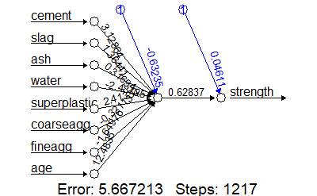

In this simple model, there is one input node for each of the eight features, followed by a single hidden node and a single output node that predicts the concrete strength.

The weights for each of the connections are also depicted, as are the bias terms (indicated by the nodes labeled with the number 1). The bias terms are numeric constants that allow the value at the indicated nodes to be shifted upward or downward, much like the intercept in a linear equation.

**Evaluating model performance**

```r
model_results <- compute(concrete_model, concrete_test[1:8])
predicted_strength <- model_results$net.result
```

compute() returns a list with two components: $neurons, which stores the neurons for each layer in the network, and $net.result, which stores the predicted values.

[output not shown]

[output cut: 40 more lines]

**Improving model performance**

Since we had only one hidden node. we will see if our model improves by assigning more number of nodes to the model.

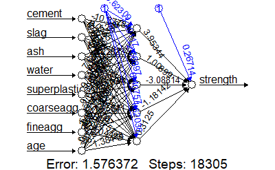

We can see that as compared to our previous model the SSE has decreased a lot and the number of steps have increased substantially which makes the model more complex.

We will evaluate our model just like previous model.

```r
print(cor(predicted_strength2, concrete_test$strength))
```

```
             [,1]
[1,] 0.6244979322
```

```r
sqrt(mean(predicted_strength2-concrete_test$strength)^2)
```

```
[1] 0.09428622755
```

## Problem 2

We have divided the paper into small rectangular cells called glyphs where each glyph denotes a character.

```r
letters<-read.csv("letterdata.csv")
str(letters)
```

```
'data.frame':   20000 obs. of  17 variables:
 $ letter: Factor w/ 26 levels "A","B","C","D",..: 20 9 4 14 7 19 2 1 10 13 ...
 $ xbox  : int  2 5 4 7 2 4 4 1 2 11 ...
 $ ybox  : int  8 12 11 11 1 11 2 1 2 15 ...
 $ width : int  3 3 6 6 3 5 5 3 4 13 ...
 $ height: int  5 7 8 6 1 8 4 2 4 9 ...
 $ onpix : int  1 2 6 3 1 3 4 1 2 7 ...
 $ xbar  : int  8 10 10 5 8 8 8 8 10 13 ...
 $ ybar  : int  13 5 6 9 6 8 7 2 6 2 ...
 $ x2bar : int  0 5 2 4 6 6 6 2 2 6 ...
 $ y2bar : int  6 4 6 6 6 9 6 2 6 2 ...
 $ xybar : int  6 13 10 4 6 5 7 8 12 12 ...
 $ x2ybar: int  10 3 3 4 5 6 6 2 4 1 ...
 $ xy2bar: int  8 9 7 10 9 6 6 8 8 9 ...
 $ xedge : int  0 2 3 6 1 0 2 1 1 8 ...
 $ xedgey: int  8 8 7 10 7 8 8 6 6 1 ...
 $ yedge : int  0 4 3 2 5 9 7 2 1 1 ...
 $ yedgex: int  8 10 9 8 10 7 10 7 7 8 ...
```

when the glyphs are scanned into the computer, they are converted into pixels and 16 statistical attributes are recorded.

we see that there are no outliers in the dataset so there is no need for tranformation of data. R packages will rescale the data for normalization

Creating training and testing dataset(80:20)

```r
letters_train <- letters[1:16000, ]
letters_test <- letters[16001:20000, ]
#install.packages("kernlab")
library(kernlab)
letter_classifier <- ksvm(letter ~ ., data = letters_train,kernel = "vanilladot")
```

The paramters of ksvm(): kernel indicate the type of non linear mapping. In this example we are using linear kernel hence “vanilladot”

There are other types of kernels as well like Gaussian RBF kernel which is used by default by ksvm()

C indiates the cost paramter which specifies the cost of violating the constraints i.e. the penalty for soft margin(Default value =1)

Evaluating model performance

```r
letter_predictions <- predict(letter_classifier, letters_test)
#tabulating the predcitions
table(letter_predictions, letters_test$letter)
```

```
letter_predictions   A   B   C   D   E   F   G   H   I   J   K   L   M   N
                 A 144   0   0   0   0   0   0   0   0   1   0   0   1   2
                 B   0 121   0   5   2   0   1   2   0   0   1   0   1   0
                 C   0   0 120   0   4   0  10   2   2   0   1   3   0   0
                 D   2   2   0 156   0   1   3  10   4   3   4   3   0   5
                 E   0   0   5   0 127   3   1   1   0   0   3   4   0   0
                 F   0   0   0   0   0 138   2   2   6   0   0   0   0   0
                 G   1   1   2   1   9   2 123   2   0   0   1   2   1   0
                 H   0   0   0   1   0   1   0 102   0   2   3   2   3   4
                 I   0   1   0   0   0   1   0   0 141   8   0   0   0   0
                 J   0   1   0   0   0   1   0   2   5 128   0   0   0   0
                 K   1   1   9   0   0   0   2   5   0   0 118   0   0   2
                 L   0   0   0   0   2   0   1   1   0   0   0 133   0   0
                 M   0   0   1   1   0   0   1   1   0   0   0   0 135   4
                 N   0   0   0   0   0   1   0   1   0   0   0   0   0 145
                 O   1   0   2   1   0   0   1   2   0   1   0   0   0   1
                 P   0   0   0   1   0   2   1   0   0   0   0   0   0   0
                 Q   0   0   0   0   0   0   8   2   0   0   0   3   0   0
                 R   0   7   0   0   1   0   3   8   0   0  13   0   0   1
                 S   1   1   0   0   1   0   3   0   1   1   0   1   0   0
                 T   0   0   0   0   3   2   0   0   0   0   1   0   0   0
                 U   1   0   3   1   0   0   0   2   0   0   0   0   0   0
                 V   0   0   0   0   0   1   3   4   0   0   0   0   1   2
                 W   0   0   0   0   0   0   1   0   0   0   0   0   2   0
                 X   0   1   0   0   2   0   0   1   3   0   1   6   0   0
                 Y   3   0   0   0   0   0   0   1   0   0   0   0   0   0
                 Z   2   0   0   0   1   0   0   0   3   4   0   0   0   0

letter_predictions   O   P   Q   R   S   T   U   V   W   X   Y   Z
                 A   2   0   5   0   1   1   1   0   1   0   0   1
                 B   0   2   2   3   5   0   0   2   0   1   0   0
                 C   2   0   0   0   0   0   0   0   0   0   0   0
                 D   5   3   1   4   0   0   0   0   0   3   3   1
                 E   0   0   2   0  10   0   0   0   0   2   0   3
                 F   0  16   0   0   3   0   0   1   0   1   2   0
                 G   1   2   8   2   4   3   0   0   0   1   0   0
                 H  20   0   2   3   0   3   0   2   0   0   1   0
                 I   0   1   0   0   3   0   0   0   0   5   1   1
                 J   1   1   3   0   2   0   0   0   0   1   0   6
                 K   0   1   0   7   0   1   3   0   0   5   0   0
                 L   0   0   1   0   5   0   0   0   0   0   0   1
                 M   0   0   0   0   0   0   3   0   8   0   0   0
                 N   0   0   0   3   0   0   1   0   2   0   0   0
                 O  99   3   3   0   0   0   3   0   0   0   0   0
                 P   2 130   0   0   0   0   0   0   0   0   1   0
                 Q   3   1 124   0   5   0   0   0   0   0   2   0
                 R   1   1   0 138   0   1   0   1   0   0   0   0
                 S   0   0  14   0 101   3   0   0   0   2   0  10
                 T   0   0   0   0   3 133   1   0   0   0   2   2
                 U   1   0   0   0   0   0 152   0   0   1   1   0
                 V   1   0   3   1   0   0   0 126   1   0   4   0
                 W   0   0   0   0   0   0   4   4 127   0   0   0
                 X   1   0   0   0   1   0   0   0   0 137   1   1
                 Y   0   7   0   0   0   3   0   0   0   0 127   0
                 Z   0   0   0   0  18   3   0   0   0   0   0 132
```

```r
prop.table(table(agreement))
```

```
agreement
  FALSE    TRUE
0.16075 0.83925
```

IMproving model performance by using Gaussian RBF kernel

```r
letter_classifier_rbf <- ksvm(letter ~ ., data = letters_train,
kernel = "rbfdot")
letter_predictions_rbf <- predict(letter_classifier_rbf,
letters_test)
agreement_rbf <- letter_predictions_rbf == letters_test$letter
table(agreement_rbf)
```

```
agreement_rbf
FALSE  TRUE
  281  3719
```

```r
prop.table(table(agreement_rbf))
```

```
agreement_rbf
  FALSE    TRUE
0.07025 0.92975
```

Thus we improved model performance from 84% to 93% by using different kernel paramter.

## Problem 3

```r
#groceries<-read.csv("groceries.csv")
```

By structuring data this way, R has constructed a set of features that record not just the items in the transactions, but also the order in which they appear. If we imagine our learning algorithm as an attempt to find a relationship among V1, V2, V3, and V4, then whole milk in V1 might be treated differently than the whole milk appearing in V2. Instead, we need a dataset that does not treat a transaction as set of positions to be filled (or not filled) with specific items, but rather as a market basket that either contains or does not contain each particular item.

We will create a sparse matrix for this purpose Since there is no benefit to storing all these zero values, a sparse matrix does not actually store the full matrix in memory; it only stores the cells that are occupied by an item. This allows the structure to be more memory efficient than an equivalently sized matrix or data frame.

```r
summary(groceries)
```

```
transactions as itemMatrix in sparse format with
 9835 rows (elements/itemsets/transactions) and
 169 columns (items) and a density of 0.02609145577

most frequent items:
      whole milk other vegetables       rolls/buns             soda
            2513             1903             1809             1715
          yogurt          (Other)
            1372            34055

element (itemset/transaction) length distribution:
sizes
   1    2    3    4    5    6    7    8    9   10   11   12   13   14   15
2159 1643 1299 1005  855  645  545  438  350  246  182  117   78   77   55
  16   17   18   19   20   21   22   23   24   26   27   28   29   32
  46   29   14   14    9   11    4    6    1    1    1    1    3    1

     Min.   1st Qu.    Median      Mean   3rd Qu.      Max.
 1.000000  2.000000  3.000000  4.409456  6.000000 32.000000

includes extended item information - examples:
            labels
1 abrasive cleaner
2 artif. sweetener
3   baby cosmetics
```

9835 rows indicate the number of transactions

Density is the number of non zero cells in the matrix. Since there are 9,835 x 169 = 1,662,115 positions in the matrix, we can calculate that a total of 1,662,115 x 0.02609146 = 43,367 items were purchased during the store’s 30 days of operation (ignoring the fact that duplicates of the same items might have been purchased).

Element length distribution denotes the number of items per transaction or itemsets. There is one item in 2159 transactions and only one transaction with 32 items.

The mean indicates average number of items per transaction which around 4.409. This value can be calculated manually as well by using the percent of density 43367/9835=4.409

```r
inspect(groceries[1:5])
```

```
    items
[1] {citrus fruit,
     margarine,
     ready soups,
     semi-finished bread}
[2] {coffee,
     tropical fruit,
     yogurt}
[3] {whole milk}
[4] {cream cheese,
     meat spreads,
     pip fruit,
     yogurt}
[5] {condensed milk,
     long life bakery product,
     other vegetables,
     whole milk}
```

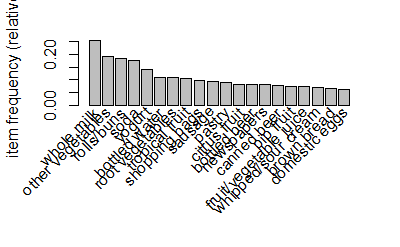

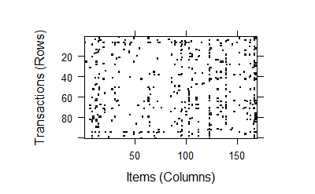

**Training the model**

```r
summary(groceryrules)
```

```
set of 463 rules

rule length distribution (lhs + rhs):sizes
  2   3   4
150 297  16

    Min.  1st Qu.   Median     Mean  3rd Qu.     Max.
2.000000 2.000000 3.000000 2.710583 3.000000 4.000000

summary of quality measures:
    support              confidence             lift
 Min.   :0.006100661   Min.   :0.2500000   Min.   :0.9932367
 1st Qu.:0.007117438   1st Qu.:0.2970711   1st Qu.:1.6229230
 Median :0.008744281   Median :0.3553719   Median :1.9332351
 Mean   :0.011539429   Mean   :0.3785573   Mean   :2.0350922
 3rd Qu.:0.012302999   3rd Qu.:0.4494849   3rd Qu.:2.3564791
 Max.   :0.074834774   Max.   :0.6600000   Max.   :3.9564774
     count
 Min.   : 60.0000
 1st Qu.: 70.0000
 Median : 86.0000
 Mean   :113.4903
 3rd Qu.:121.0000
 Max.   :736.0000

mining info:
      data ntransactions support confidence
 groceries          9835   0.006       0.25
```

We’ll start with a confidence threshold of 0.25, which means that in order to be included in the results, the rule has to be correct at least 25 percent of the time. This will eliminate the most unreliable rules, while allowing some room for us to modify behavior with targeted promotions.

minlength is 2 which indicates that at least 2 items should be present in the transaction

The rule length distribution tells us how many rules have each count of items. In our rule set, 150 rules have only two items, while 297 have three, and 16 have four rules.

The summary of quality measures denote the support, confidence and lift. if most or all of the rules had support and confidence very near the minimum thresholds, this would mean that we may have set the bar too high. This is not the case here, as there are many rules with much higher values of each.

The lift of a rule measures how much more likely one item or itemset is purchased relative to its typical rate of purchase. A large lift value is therefore a strong indicator that a rule is important, and reflects a true connection between the items.

```r
inspect(groceryrules[1:3])
```

```
    lhs             rhs               support        confidence
[1] {pot plants} => {whole milk}      0.006914082359 0.4000000000
[2] {pasta}      => {whole milk}      0.006100660905 0.4054054054
[3] {herbs}      => {root vegetables} 0.007015760041 0.4312500000
    lift        count
[1] 1.565459610 68
[2] 1.586614470 60
[3] 3.956477379 69
```

In spite of the fact that the confidence and lift are high, does {potted plants} ??? {whole milk} seem like a very useful rule? Probably not, as there doesn’t seem to be a logical reason why someone would be more likely to buy milk with a potted plant.

We will try to improve the performance of the model.

```r
inspect(sort(groceryrules, by = "lift")[1:5])
```

```
    lhs                   rhs                         support   confidence        lift count
[1] {herbs}            => {root vegetables}    0.007015760041 0.4312500000 3.956477379    69
[2] {berries}          => {whipped/sour cream} 0.009049313676 0.2721712538 3.796885505    89
[3] {other vegetables,
     tropical fruit,
     whole milk}       => {root vegetables}    0.007015760041 0.4107142857 3.768073694    69
[4] {beef,
     other vegetables} => {root vegetables}    0.007930859176 0.4020618557 3.688692491    78
[5] {other vegetables,
     tropical fruit}   => {pip fruit}          0.009456024403 0.2634560907 3.482648725    93
```

The arules package includes a sort() function that can be used to reorder the list of rules so that the ones with the highest or lowest values of the quality measure come first.

Taking subsets of association rules

The subset() function provides a method to search for subsets of transactions, items, or rules.

```r
inspect(berryrules)
```

```
    lhs          rhs                  support        confidence
[1] {berries} => {whipped/sour cream} 0.009049313676 0.2721712538
[2] {berries} => {yogurt}             0.010574478902 0.3180428135
[3] {berries} => {other vegetables}   0.010269445857 0.3088685015
[4] {berries} => {whole milk}         0.011794611083 0.3547400612
    lift        count
[1] 3.796885505  89
[2] 2.279847719 104
[3] 1.596280459 101
[4] 1.388328095 116
```

The operator %in% means that at least one of the items must be found in the list you defined.

Saving association rules to a file

```r
write(groceryrules, file = "groceryrules.csv",
sep = ",", quote = TRUE, row.names = FALSE)
```

This creates a data frame with the rules in the factor format, and numeric vectors for support, confidence, and lift.

```r
str(groceryrules_df)
```

```
'data.frame':   463 obs. of  5 variables:
 $ rules     : Factor w/ 463 levels "{baking powder} => {other vegetables}",..: 340 302 207 206 208 341 402 21 139 140 ...
 $ support   : num  0.00691 0.0061 0.00702 0.00773 0.00773 ...
 $ confidence: num  0.4 0.405 0.431 0.475 0.475 ...
 $ lift      : num  1.57 1.59 3.96 2.45 1.86 ...
 $ count     : num  68 60 69 76 76 69 70 67 63 88 ...
```